# STOR 455 Assignment 8

```r
library(readr)
library(mosaic)
library(dplyr)

source('~/Documents/(2) Sophomore Year/Second Semester (SPR 20)/STOR 455/R Scripts/HistNormal.R')
```

```r
UsedCars <- read_csv("~/Documents/(2) Sophomore Year/Second Semester (SPR 20)/STOR 455/CSV Files/UsedCars.csv")
```

## PREPARATION

```r
Cars = as.data.frame(table(UsedCars$Model))
names(Cars)[1] = "Model"
names(Cars)[2] = "Count"
FindModel = subset(Cars, Count>=1000)
```

```r
set.seed(12121)

#AMERICAN

FordFusion = sample_n(subset(UsedCars, Model=="FusionSE"), 100)
FordFusion$Country = "US"
FordFusion$Type = "Car"
FordExpeditionSUV = sample_n(subset(UsedCars, Model=="Expedition"), 100)
FordExpeditionSUV$Country = "US"
FordExpeditionSUV$Type = "SUV"

#JAPANESE

HondaAccord = sample_n(subset(UsedCars, Model=="Accord"), 100)
HondaAccord$Country = "Germany"
HondaAccord$Type = "Car"
HondaPilotSUV = sample_n(subset(UsedCars, Model=="Pilot4WD"), 100)
HondaPilotSUV$Country = "Germany"
HondaPilotSUV$Type = "SUV"

#GERMAN

MercedesSUV = sample_n(subset(UsedCars, Model=="GLK-ClassGLK350"), 100)
MercedesSUV$Country = "Japan"
MercedesSUV$Type = "SUV"
MercedesCLA = sample_n(subset(UsedCars, Model=="CLA-ClassCLA250"), 100)
MercedesCLA$Country = "Japan"
MercedesCLA$Type = "Car"

CarsSix = rbind(FordFusion, FordExpeditionSUV, HondaAccord, HondaPilotSUV, MercedesCLA, MercedesSUV)
```

## ONE WAY ANOVA

### QUESTION 1

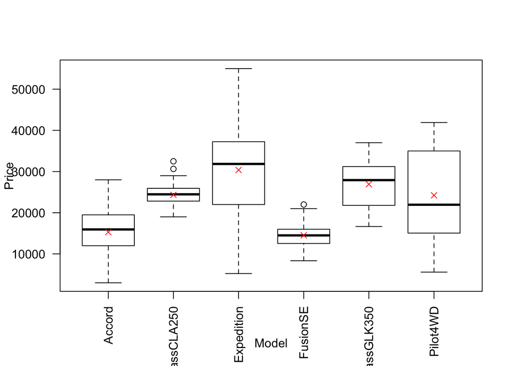

```r
boxplot(Price~Model, data=CarsSix, las=2)
means = tapply(CarsSix$Price,CarsSix$Model,mean)
points(means,col="red",pch=4)
```

### QUESTION 2

```r
tapply(CarsSix$Price,CarsSix$Model,mean)
```

```
##          Accord CLA-ClassCLA250      Expedition        FusionSE GLK-ClassGLK350
##        15302.57        24340.30        30383.36        14522.34        26921.73
##        Pilot4WD
##        24225.67
```

```r
round(tapply(CarsSix$Price,CarsSix$Model,sd),2)
```

```
##          Accord CLA-ClassCLA250      Expedition        FusionSE GLK-ClassGLK350
##         5572.95         2494.01        10673.09         2775.69         5905.79
##        Pilot4WD
##        10910.11
```

```r
mean(CarsSix$Price)
```

```
## [1] 22615.99
```

```r
sd(CarsSix$Price)
```

```
## [1] 9255.299
```

### QUESTION 3

Based on the boxplots and summary statistics, there appears to be significant difference in the mean prices. The means range from 14522.34 up to 30383.36, which is logical considering we are comparing normal cars to SUV’s which tend to be more expensive.

Also, when looking at the standard deviations of the prices, we can see they vary from 2494.01 up to 10910.11, making the condition of *constant variance* less likely to be satisfied in the ANOVA for means model.

### QUESTION 4

```r
amodPrice=aov(Price~factor(Model),data=CarsSix)
summary(amodPrice)
```

```
##                Df    Sum Sq   Mean Sq F value Pr(>F)
## factor(Model)   5 2.034e+10 4.069e+09   78.04 <2e-16 ***
## Residuals     594 3.097e+10 5.213e+07
## ---
## Signif. codes:  0 '***' 0.001 '**' 0.01 '*' 0.05 '.' 0.1 ' ' 1
```

*Null Hypothesis*: The mean price of all car models are the same

*Alternate Hyothesis*: At least one of the car models has a different mean price

From the *aov* test, a *p-value of <2e-16* implies that we can reject the null hypothesis and conclude that there is a significant difference between the mean prices of the car models.

### QUESTION 5

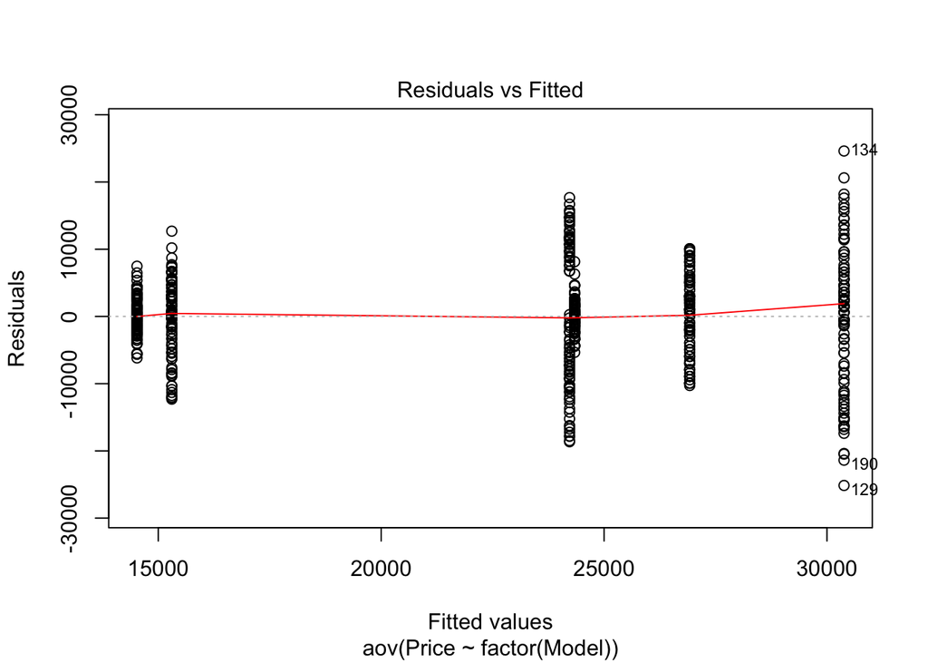

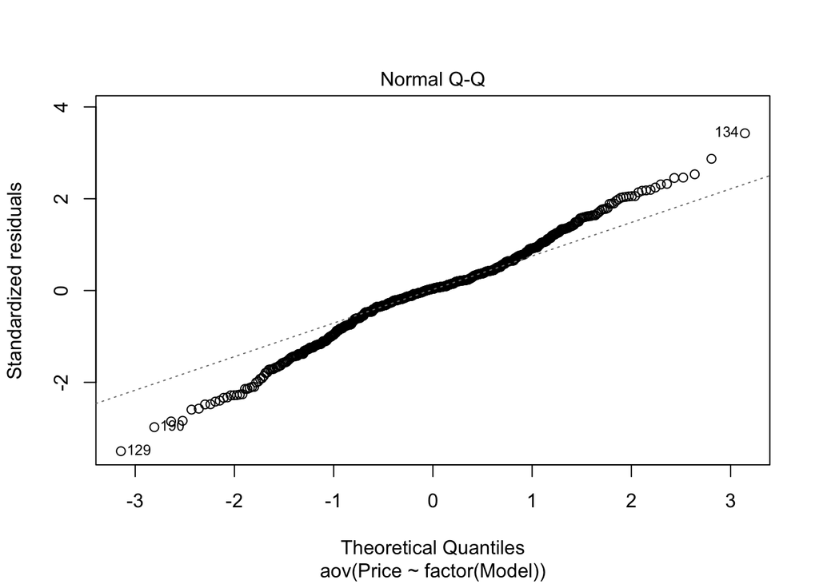

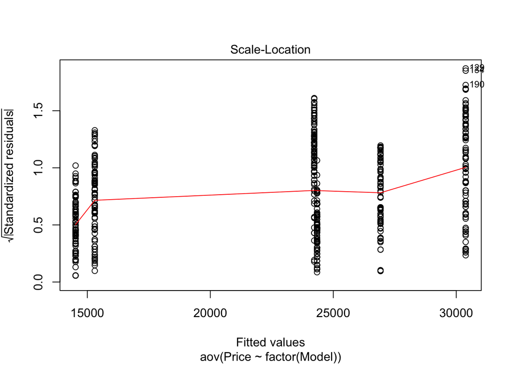

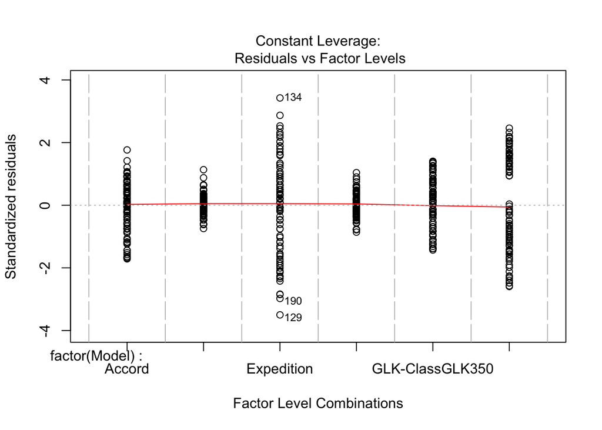

```r
plot(amodPrice)
```

Based on the “Residuals vs Fitted” plot, we can see the values vary uniformally around 0. This would imply *equality of variances*, however, the standard deviations of the car models vary greatly, making the condition of constant variance less likely to be satisfied.

Based on the “Normal Q-Q” plot, we can see that the data points follow the line relatively well, with some deviation at the ends. Thus, we can safely assume the model satisfies *normality of the residuals*.

### QUESTION 6

```r
TukeyHSD(amodPrice)
```

```
##   Tukey multiple comparisons of means
##     95% family-wise confidence level
##
## Fit: aov(formula = Price ~ factor(Model), data = CarsSix)
##
## $`factor(Model)`
##                                      diff         lwr         upr     p adj
## CLA-ClassCLA250-Accord            9037.73   6118.3008  11957.1592 0.0000000
## Expedition-Accord                15080.79  12161.3608  18000.2192 0.0000000
## FusionSE-Accord                   -780.23  -3699.6592   2139.1992 0.9733561
## GLK-ClassGLK350-Accord           11619.16   8699.7308  14538.5892 0.0000000
## Pilot4WD-Accord                   8923.10   6003.6708  11842.5292 0.0000000
## Expedition-CLA-ClassCLA250        6043.06   3123.6308   8962.4892 0.0000001
## FusionSE-CLA-ClassCLA250         -9817.96 -12737.3892  -6898.5308 0.0000000
## GLK-ClassGLK350-CLA-ClassCLA250   2581.43   -337.9992   5500.8592 0.1176376
## Pilot4WD-CLA-ClassCLA250          -114.63  -3034.0592   2804.7992 0.9999975
## FusionSE-Expedition             -15861.02 -18780.4492 -12941.5908 0.0000000
## GLK-ClassGLK350-Expedition       -3461.63  -6381.0592   -542.2008 0.0096649
## Pilot4WD-Expedition              -6157.69  -9077.1192  -3238.2608 0.0000000
## GLK-ClassGLK350-FusionSE         12399.39   9479.9608  15318.8192 0.0000000
## Pilot4WD-FusionSE                 9703.33   6783.9008  12622.7592 0.0000000
## Pilot4WD-GLK-ClassGLK350         -2696.06  -5615.4892    223.3692 0.0893622
```

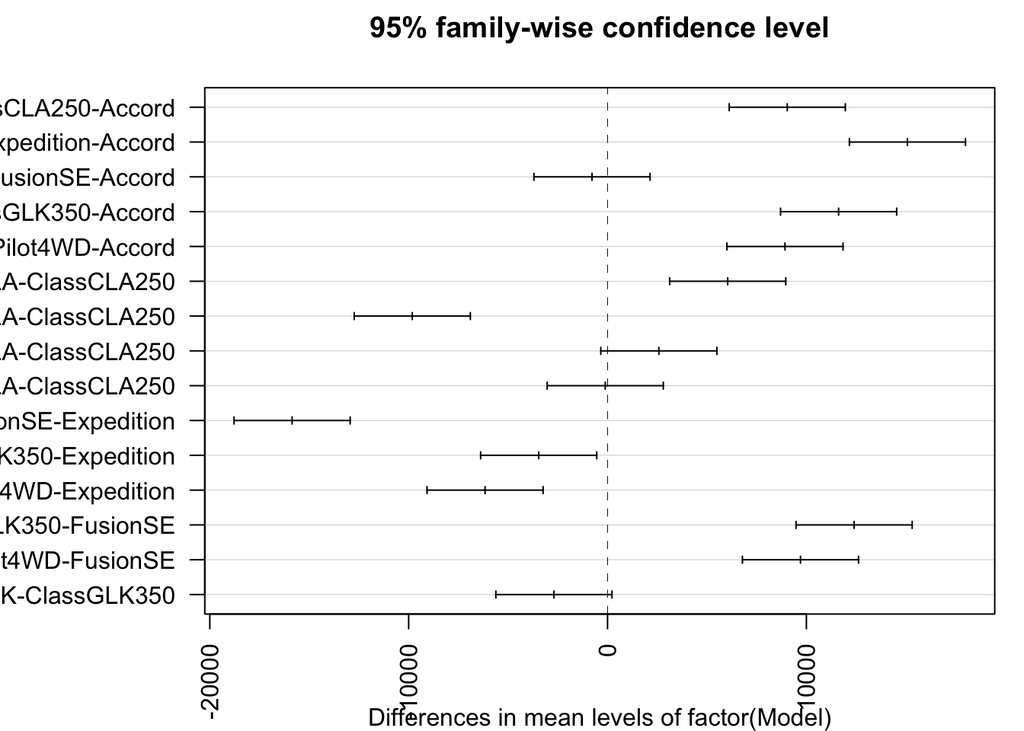

```r
origpar=par()          #saves current graphic parameters
par(mar=c(4,7,3,1))    #adjusts margins for wider labels
hsd=TukeyHSD(amodPrice)     #save the Tukey  intervals
plot(hsd,las=2)        #plot the intervals
```

Based on the *Turkey HSD methods*, we can see that there are multiple instance where the confidence interval does not cross the mean 0. This implies that there is a significant difference in mean prices, keeping with our previous assesment.

## TWO WAY ANOVA

### QUESTION 7

```r
amodCountryType=aov(Price~Country+Type,data=CarsSix)
summary(amodCountryType)
```

```
##              Df    Sum Sq   Mean Sq F value   Pr(>F)
## Country       2 3.450e+09 1.725e+09   29.06 9.07e-13 ***
## Type          1 1.248e+10 1.248e+10  210.26  < 2e-16 ***
## Residuals   596 3.538e+10 5.936e+07
## ---
## Signif. codes:  0 '***' 0.001 '**' 0.01 '*' 0.05 '.' 0.1 ' ' 1
```

*Null Hypothesis (A)*: The mean price of all cars based on country will be the same

*Alternate Hypothesis (A)*: At least one the cars has a different mean price based on country

*Null Hypothesis (B)*: The mean price of all cars based on type will be the same

*Alternate Hypothesis (B)*: At least one the cars has a different mean price based on type

Based on the above ANOVA test with *p-values 9.07e-13 and < 2e-16*, we can reject the null hypotheses and conclude that there is a significant difference in a car’s mean price based on country and type.

```r
TukeyHSD(amodCountryType)
```

```
##   Tukey multiple comparisons of means
##     95% family-wise confidence level
##
## Fit: aov(formula = Price ~ Country + Type, data = CarsSix)
##
## $Country
##                    diff        lwr       upr     p adj
## Japan-Germany  5866.895  4056.6283  7677.162 0.0000000
## US-Germany     2688.730   878.4633  4498.997 0.0015043
## US-Japan      -3178.165 -4988.4317 -1367.898 0.0001252
##
## $Type
##            diff      lwr      upr p adj
## SUV-Car 9121.85 7886.365 10357.34     0
```

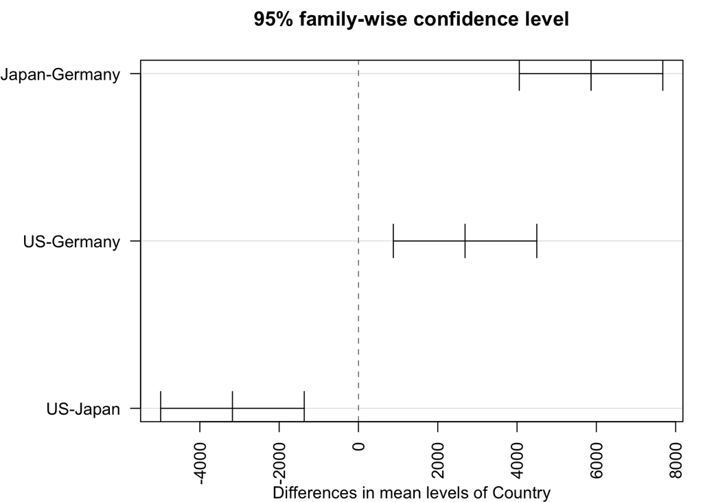

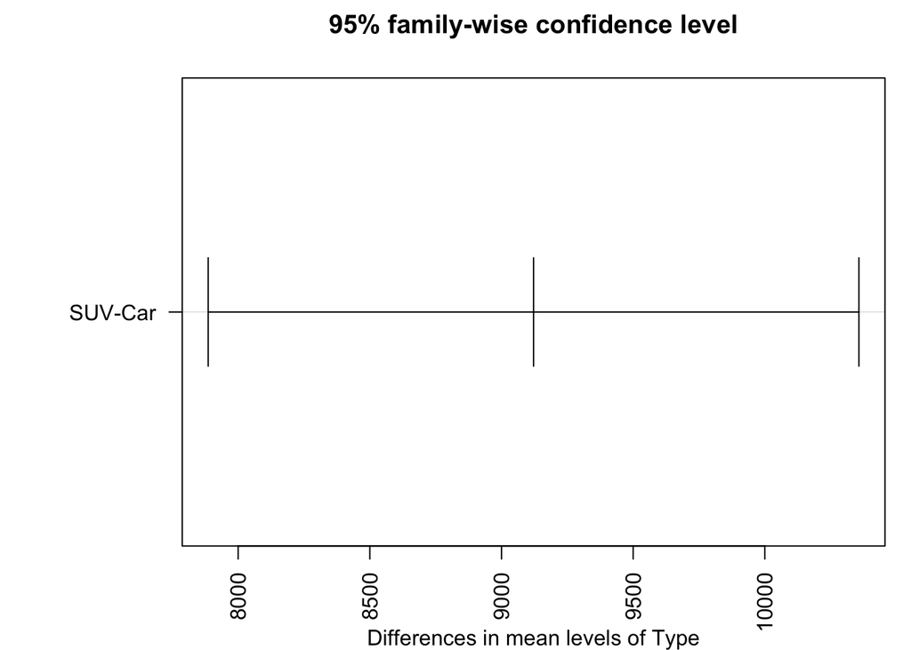

```r
origpar=par()          #saves current graphic parameters
par(mar=c(4,7,3,1))    #adjusts margins for wider labels
hsd=TukeyHSD(amodCountryType)     #save the Tukey  intervals
plot(hsd,las=2)        #plot the intervals
```

Keeping with the above conclusion, the *Turkey HSD methods* show that none of the intervals cross the mean 0, implying that there is a significant difference in mean price based on country and type.

## QUESTION 8

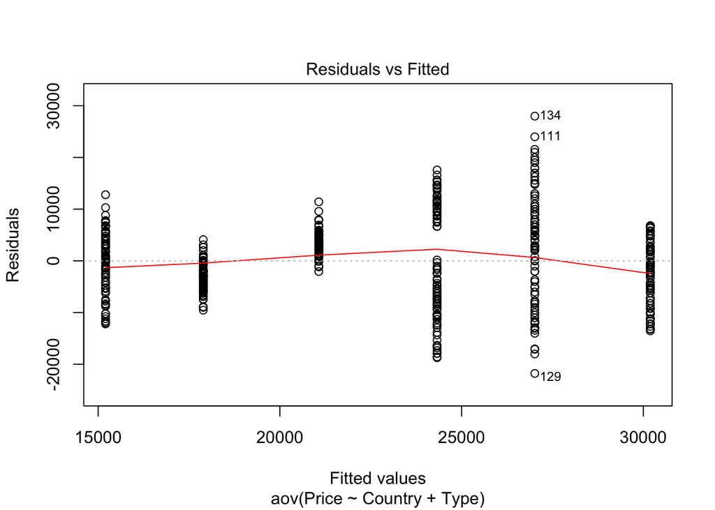

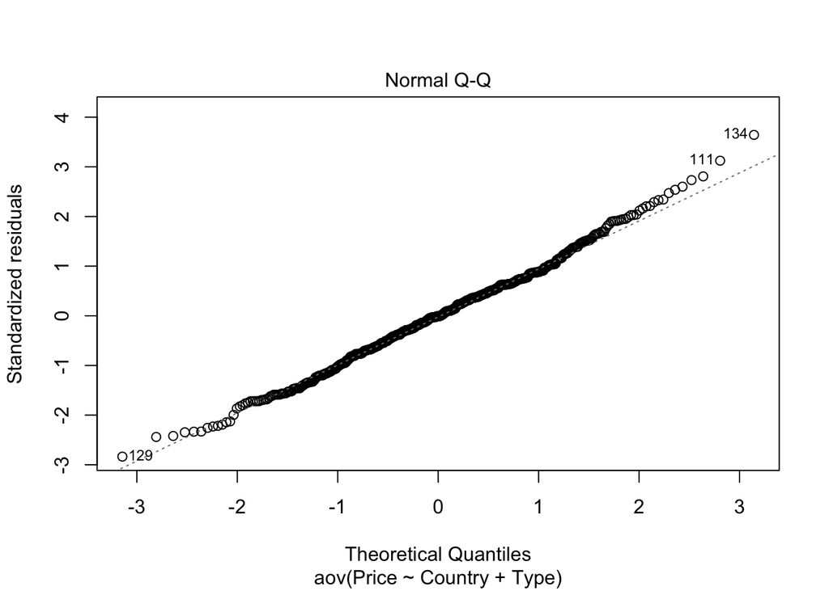

```
## hat values (leverages) are all = 0.006666667
##  and there are no factor predictors; no plot no. 5
```

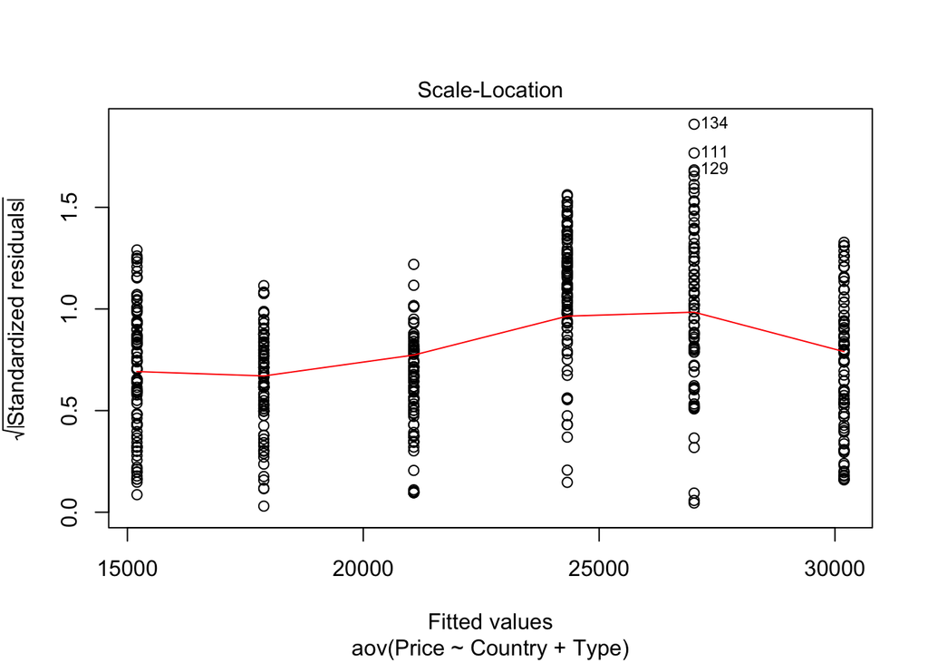

```r
plot(amodCountryType)
```

```r
summary(amodCountryType)
```

```
##              Df    Sum Sq   Mean Sq F value   Pr(>F)
## Country       2 3.450e+09 1.725e+09   29.06 9.07e-13 ***
## Type          1 1.248e+10 1.248e+10  210.26  < 2e-16 ***
## Residuals   596 3.538e+10 5.936e+07
## ---
## Signif. codes:  0 '***' 0.001 '**' 0.01 '*' 0.05 '.' 0.1 ' ' 1
```

Based on the “Q-Q Normal” plot, the data points seem to fit the line very well with little deviation at the ends, implying that the model satisfies *normality of the residuals*.

## QUESTION 9

```r
amodCountryTypeInter=aov(Price~Country+Type+Country*Type,data=CarsSix)
summary(amodCountryTypeInter)
```

```
##               Df    Sum Sq   Mean Sq F value   Pr(>F)
## Country        2 3.450e+09 1.725e+09   33.09 2.38e-14 ***
## Type           1 1.248e+10 1.248e+10  239.41  < 2e-16 ***
## Country:Type   2 4.412e+09 2.206e+09   42.31  < 2e-16 ***
## Residuals    594 3.097e+10 5.213e+07
## ---
## Signif. codes:  0 '***' 0.001 '**' 0.01 '*' 0.05 '.' 0.1 ' ' 1
```

*Null Hypothesis (A)*: The price of the cars is not affected by country

*Alternate Hypothesis (A)*: At least one car’s price is affected by country

*Null Hypothesis (B)*: The price of the cars is not affected by type

*Alternate Hypothesis (B)*: At least one car’s price is affected by type

*Null Hypothesis (C)*: The price of the cars is not affected by the interaction between country and type

*Alternate Hypothesis (C)*:At least one car’s price is affected by the interaction of country and price

Based on the above ANOVA test with *p-values 2.38e-14, < 2e-16, and < 2e-16*, we can reject the null hypotheses and conclude that a car’s price is affected by country, type, and the interaction of country and type.

```r
TukeyHSD(amodCountryTypeInter)
```

```
##   Tukey multiple comparisons of means
##     95% family-wise confidence level
##
## Fit: aov(formula = Price ~ Country + Type + Country * Type, data = CarsSix)
##
## $Country
##                    diff        lwr       upr     p adj
## Japan-Germany  5866.895  4170.3877  7563.402 0.0000000
## US-Germany     2688.730   992.2227  4385.237 0.0006287
## US-Japan      -3178.165 -4874.6723 -1481.658 0.0000379
##
## $Type
##            diff      lwr      upr p adj
## SUV-Car 9121.85 7964.006 10279.69     0
##
## $`Country:Type`
##                             diff         lwr       upr     p adj
## Japan:Car-Germany:Car    9037.73   6118.3008 11957.159 0.0000000
## US:Car-Germany:Car       -780.23  -3699.6592  2139.199 0.9733561
## Germany:SUV-Germany:Car  8923.10   6003.6708 11842.529 0.0000000
## Japan:SUV-Germany:Car   11619.16   8699.7308 14538.589 0.0000000
## US:SUV-Germany:Car      15080.79  12161.3608 18000.219 0.0000000
## US:Car-Japan:Car        -9817.96 -12737.3892 -6898.531 0.0000000
## Germany:SUV-Japan:Car    -114.63  -3034.0592  2804.799 0.9999975
## Japan:SUV-Japan:Car      2581.43   -337.9992  5500.859 0.1176376
## US:SUV-Japan:Car         6043.06   3123.6308  8962.489 0.0000001
## Germany:SUV-US:Car       9703.33   6783.9008 12622.759 0.0000000
## Japan:SUV-US:Car        12399.39   9479.9608 15318.819 0.0000000
## US:SUV-US:Car           15861.02  12941.5908 18780.449 0.0000000
## Japan:SUV-Germany:SUV    2696.06   -223.3692  5615.489 0.0893622
## US:SUV-Germany:SUV       6157.69   3238.2608  9077.119 0.0000000
## US:SUV-Japan:SUV         3461.63    542.2008  6381.059 0.0096649
```

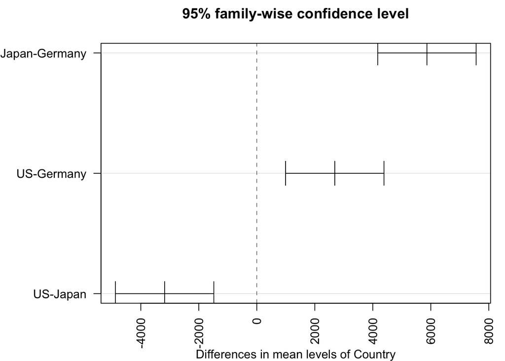

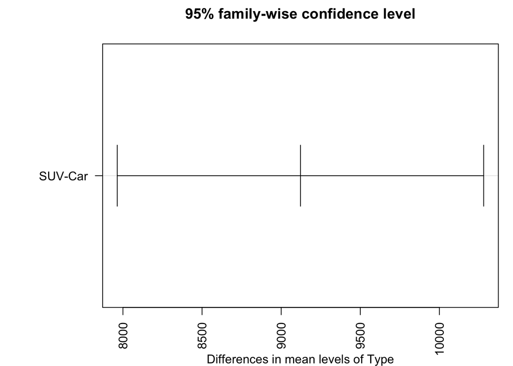

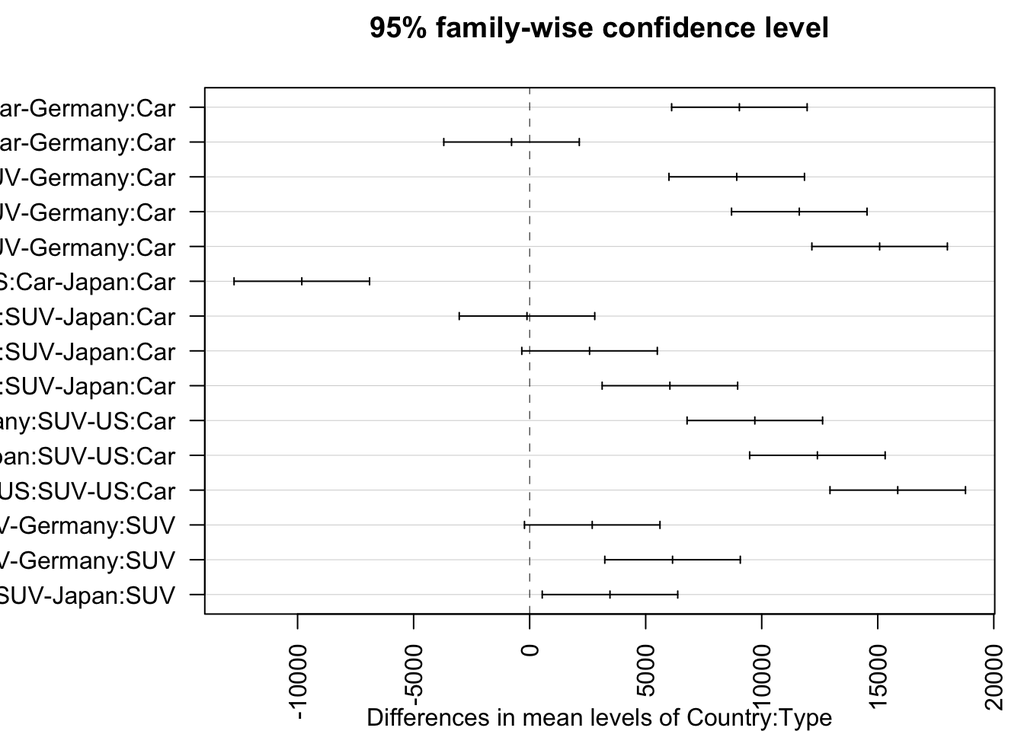

```r
origpar=par()          #saves current graphic parameters
par(mar=c(4,7,3,1))    #adjusts margins for wider labels
hsd=TukeyHSD(amodCountryTypeInter)     #save the Tukey  intervals
plot(hsd,las=2)        #plot the intervals
```

Keeping with the above conclusion, the *Turkey HSD methods* show that there are intervals that do not cross the mean 0, implying that the price of a car is affected by country, type, and the interaction of country and type.

## QUESTION 10

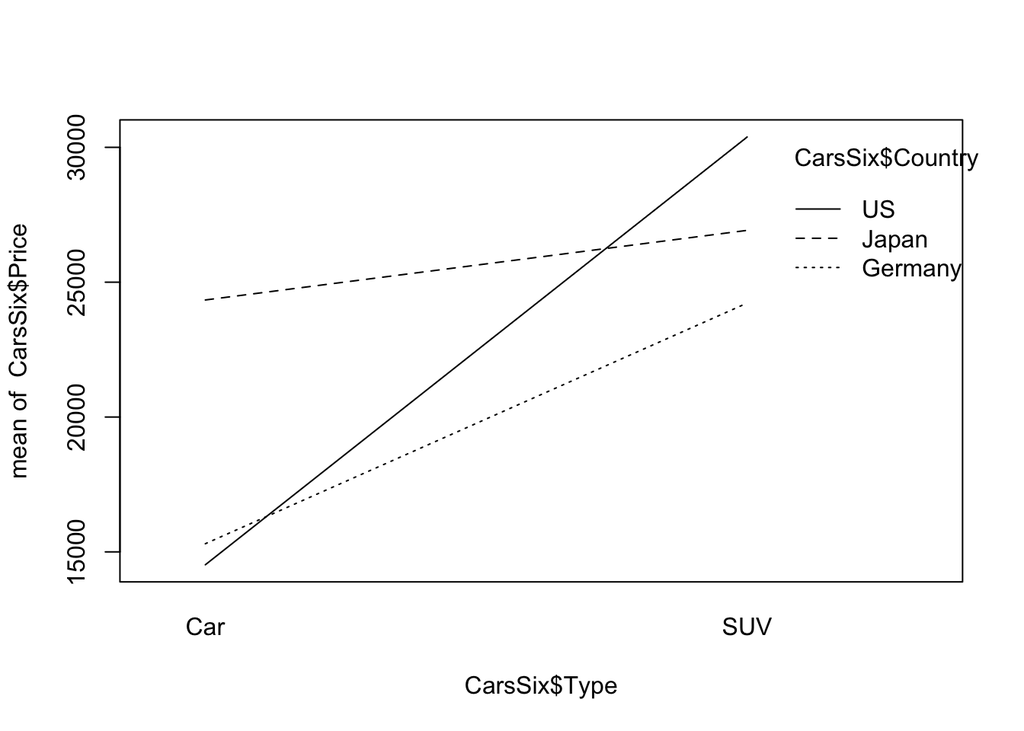

```r
interaction.plot(CarsSix$Type,CarsSix$Country,CarsSix$Price)
```

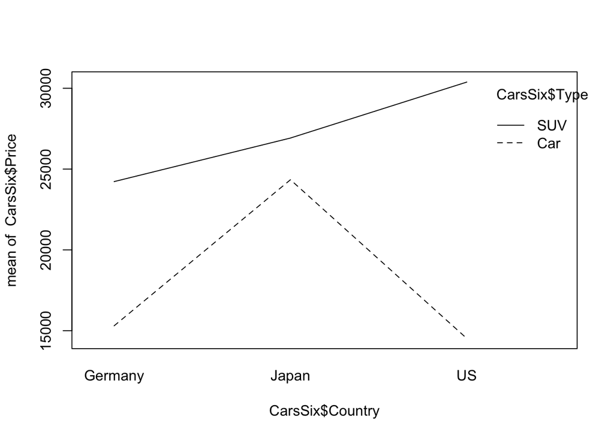

```r
interaction.plot(CarsSix$Country,CarsSix$Type,CarsSix$Price)
```

In the first interaction plot, cars of US origin clearly have a different slope from Japan and German bred cars. Because our sample is realtively large for each, we can also show that Japanese and German cars have different slopes, although they are somewhat similar.

In the second interaction plot, it is pretty obvious that SUV and Car present very different trends as country of origin shifts.

Thus, based on these differences in slopes across both models, we can support that the intraction between type and country of origin are significant in modeling the price of a car.

## ADDITIONAL TOPICS

### QUESTION 11

```r
MultiCarMod = lm(Price~Model, data=CarsSix)
summary(MultiCarMod)
```

```
##
## Call:
## lm(formula = Price ~ Model, data = CarsSix)
##
## Residuals:
##      Min       1Q   Median       3Q      Max
## -25144.4  -3388.1    270.5   3695.7  24609.6
##
## Coefficients:
##                      Estimate Std. Error t value Pr(>|t|)
## (Intercept)           15302.6      722.0  21.193   <2e-16 ***
## ModelCLA-ClassCLA250   9037.7     1021.1   8.851   <2e-16 ***
## ModelExpedition       15080.8     1021.1  14.769   <2e-16 ***
## ModelFusionSE          -780.2     1021.1  -0.764    0.445
## ModelGLK-ClassGLK350  11619.2     1021.1  11.379   <2e-16 ***
## ModelPilot4WD          8923.1     1021.1   8.739   <2e-16 ***
## ---
## Signif. codes:  0 '***' 0.001 '**' 0.01 '*' 0.05 '.' 0.1 ' ' 1
##
## Residual standard error: 7220 on 594 degrees of freedom
## Multiple R-squared:  0.3965, Adjusted R-squared:  0.3914
## F-statistic: 78.04 on 5 and 594 DF,  p-value: < 2.2e-16
```

Each coefficent is based on the reference group (“Accord”). So, for example, if we wanted to see our average price change when switching from an Accord to a FusionSE, the price would decrease by -780.2 on average. The same principle applies for the other models whose prices would all increase on average compared to the reference.

## QUESTION 12

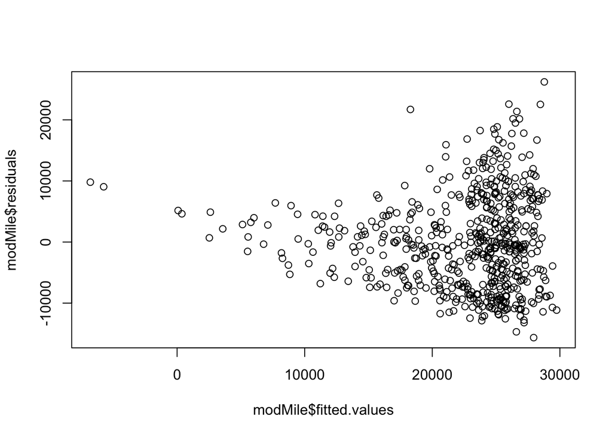

```r
modMile = aov(Price~Mileage, data = CarsSix)

plot(modMile$residuals~modMile$fitted.values)
```

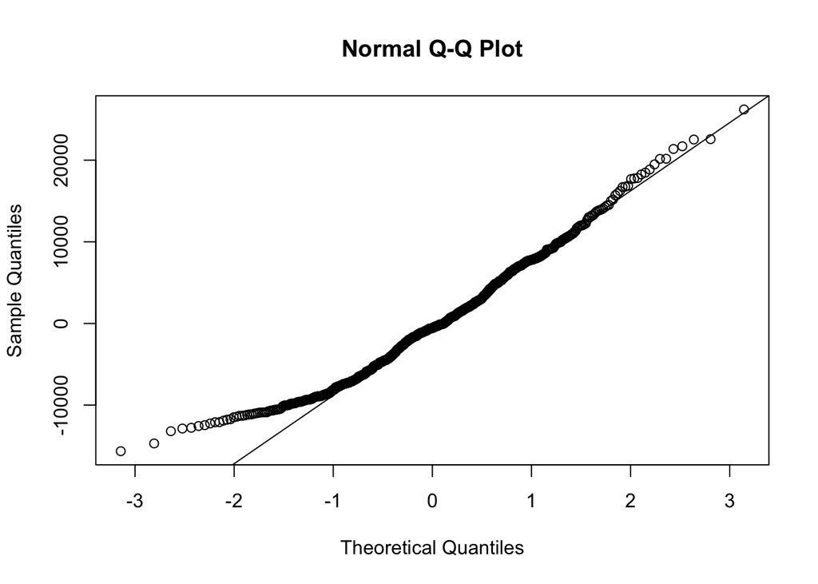

```r
qqnorm(modMile$residuals)
qqline(modMile$residuals)
```

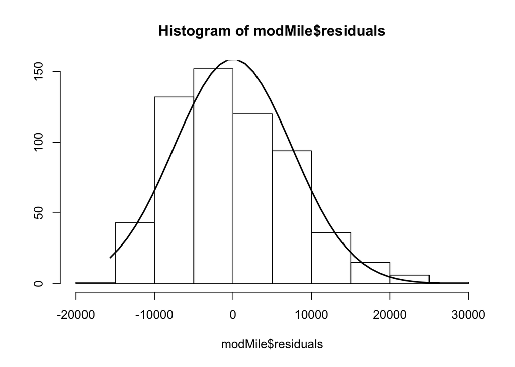

```r
hist.normal(modMile$residuals)
```

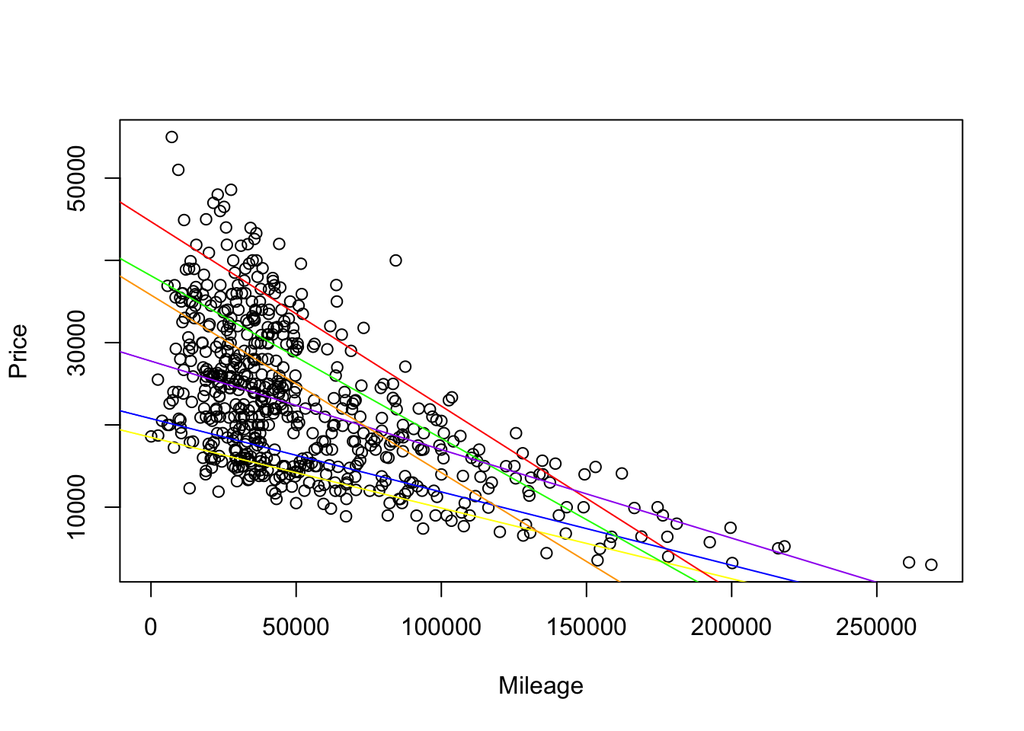

```r
lme1 = lm(Price ~ Mileage, data=FordFusion)
lme2 = lm(Price ~ Mileage, data=FordExpeditionSUV)
lme3 = lm(Price ~ Mileage, data=HondaAccord)
lme4 = lm(Price ~ Mileage, data=HondaPilotSUV)
lme5 = lm(Price ~ Mileage, data=MercedesCLA)
lme6 = lm(Price ~ Mileage, data=MercedesSUV)

plot(Price ~ Mileage, data=CarsSix)
abline(lme1, col='yellow')
abline(lme2, col='red')
abline(lme3, col='blue')
abline(lme4, col='green')
abline(lme5, col='purple')
abline(lme6, col='orange')
```

```r
modModelMile = aov(Price~factor(Model) + Mileage, data = CarsSix)
anova(modModelMile)
```

|  | Df | Sum Sq | Mean Sq | F value | Pr(>F) |
| --- | --- | --- | --- | --- | --- |
| factor(Model) | 5 | 20342903076 | 4068580615 | 224.8902 | 2.398169e-134 |
| Mileage | 1 | 20239567551 | 20239567551 | 1118.7392 | 1.269598e-138 |
| Residuals | 593 | 10728204960 | 18091408 | NA | NA |